# Predicting Wildfires Based on Temperature and Precipitation

## Introduction

This document is part of my Data Incubator application.

In Colorado, more and more people are moving to the wildland-urban interface. We have seen property values in our scenic mountain towns increasing steadily. Just 30 minutes from Denver, the town of Evergreen offers mountain-living with the convenience of living close to a major city with all the amenities one could want.

This growth in population and construction is at risk to wildland fires. Climate change has increased the frequency and intensity of wildfires in the Western US over the past decade and this problem is only expected to get worse in the future. In the past decade alone, Colorado has experience at least 3 costly fire events that destroyed property and lives.

- The High Park Fire in 2012 near Ft. Collins destroyed estimated to cost $33.5 million
- The Waldo Canyon fire in 2012 near Colorado Springs estimated to $453.7 million.
- The Four mile Canyon fire in 2014 near Boulder that cost $217 million.

In other populated Western States like California and Washington, wildfires pose a similar if not greater risk to property than Colorado. One only needs to look to the recent Northern California fires that affected Sonoma and Napa counties that cost a record $9.4 billion in insured damage.

The ability to quantify neighborhood and community risk to wildfires would be of economic value for real-estate developers and insurance agencies.

I am proposing to build predictive models that will estimate the likelihood of a wildfire for the Western United States using data from NASA and NOAA satellite products. These models will use a relatively untapped data resource of NASA and NOAA remote-sensor satellite products.

To demonstrate the feasibility of this project, I will use Palmer Drought Index data that uses temperature and precipitation satellite products from National Oceanic and Atmospheric Administration (NOAA) to plot the mean drought index for Colorado from 1980 to 2014. I will also plot the number of wildfires in Colorado from 1980 to 2014 as well.

I will use the following packages to create the plot. The tidyverse package is a general data-wrangling package that also includes ggplot2 graphical package. The ncdf4 package opens connections to .nc gridded array files that are commonly used by NOAA for efficiently storing multi-dimensional data. The sf package will be used to open up a shape file of wildfire locations.

```r
# libraries
library(tidyverse)
library(ncdf4)
library(sf)
library(raster)
```

```r
# knitr options
knitr::opts_chunk$set(fig.width = 8, fig.height = 6)
```

## Drought Index

Opening connection to Palmer Drought Index (PDI) file from Colorado.

```r
# open drought index nc conncection
di_nc <- nc_open("./data/pdi_colorado.nc")
di_nc
```

```
## File ./data/pdi_colorado.nc (NC_FORMAT_CLASSIC):
##
##      1 variables (excluding dimension variables):
##         float pdsi[lon,lat,time]
##             statistic: Mean
##             missing_value: -99999
##             dataset: Dai Palmer Drought Severity Index: Self-calibrated
##             long_name: Monthly Self-calibrated Palmer Drought Severity Index using Penman-Monteith PE
##             level_desc: Surface
##             var_desc: Palmer Drought Severity Index
##             least_significant_digit: 2
##             units: Standardized Units of Relative Dry and Wet
##             actual_range: 1.62338197231293
##              actual_range: 3.34349775314331
##             valid_range: -100
##              valid_range: 100
##
##      3 dimensions:
##         lat  Size:3
##             units: degrees_north
##             long_name: Latitude
##             actual_range: 36.25
##              actual_range: 41.25
##             standard_name: latitude
##             axis: Y
##         lon  Size:3
##             units: degrees_east
##             long_name: Longitude
##             actual_range: -108.75
##              actual_range: -103.75
##             standard_name: longitude
##             axis: X
##         time  Size:420   *** is unlimited ***
##             units: hours since 1800-01-01 00:00:0.0
##             actual_range: 1577832
##              actual_range: 1883904
##             long_name: Time
##             delta_t: 0000-01-00 00:00:00
##             avg_period: 0000-01-00 00:00:00
##             standard_name: time
```

[output cut: 23 more lines]

```
## Palmer Drought Severity Index (PDSI) during 1900-2008. J. Geophys.
## Res., 116, D12115, doi:10.1029/2010JD015541.
## Dai, A., K. E. Trenberth, and T. Qian, 2004: A global data set of
## Palmer Drought Severity Index for 1870-2002: Relationship with soil
## moisture and effects of surface warming. J. Hydrometeorology, 5,
## 1117-1130. Data source: Dr. A. Dai/NCAR (adai@ucar.edu). See
## http://www.cgd.ucar.edu/cas/catalog/climind/pdsi.html for updates.
## WARNING: PDSI and scPDSI over the higher latitudes (e.g., >50deg.)
## may not be a good proxy of soil moisutre content. Also, PDSI and
## scPDSI are highly autocorrelated indices not good at resolving
## sub-seasonal variations.  Please use with caution!
## This is a normalized version so that every grid box has the same
## s.d. as that in the central U.S. during the calibr. period (1950-79)
##         dataset_title: Palmer Drought Severity Index
##         NCO: 4.2.6
```

Wrangling PDI from 3-D array to a 2-D matrix.

```r
# extract lat/lon points and expand grid
lat <- ncvar_get(di_nc, varid = "lat")
# lons need to be negative rather than degrees west
lon <- ncvar_get(di_nc, varid = "lon")
coords <- as.matrix(expand.grid(lon,lat))
# extract recent montly air temp where each month is a column
pdsi <- ncvar_get(di_nc, varid = "pdsi")

# matrix
pdsi_mat <- apply(pdsi, 3, as.vector)
# create date column names
date <- as.character(seq(as.Date("1980-01-01"), as.Date("2014-12-01"),
                         by = "month"))
# assign date names to temp matrix
colnames(pdsi_mat) <- date
```

Preparing data frame for plotting.

```r
# pdsi matrix
colnames(coords) <- c("lon", "lat")

group <- 1:9
# group
pdsi_df <- data.frame(group, coords, pdsi_mat)

# date for plotting
date_col <- as.data.frame(seq(as.Date("1980-01-01"), as.Date("2014-12-01"),
                        by = "month"))

# make temp matrix and take mean for state
co_di <- pdsi_df %>%
  dplyr::select(-lon, -lat) %>%
  gather(key = date, value = pdi, -group) %>%
  mutate(pdi_invert = -(pdi),
    Date = as.Date(gsub("X", "", gsub("\\.","-", date)))) %>%
  group_by(Date) %>%
  summarise(mean_pdi_invert = mean(pdi_invert)) %>%
  mutate(month = factor(months(Date),
   levels = c("January", "February", "March", "April", "May", "June", "July",
               "August", "September", "October", "November", "December")))
```

### Plot of Colorado Monthly Mean Drought Index 1980-2014

Plot of inverted drought index (measure that accounts for temperature and precipitation) for Colorado by Month. General trend across the state and for all months indicates the state is getting dryer over time.

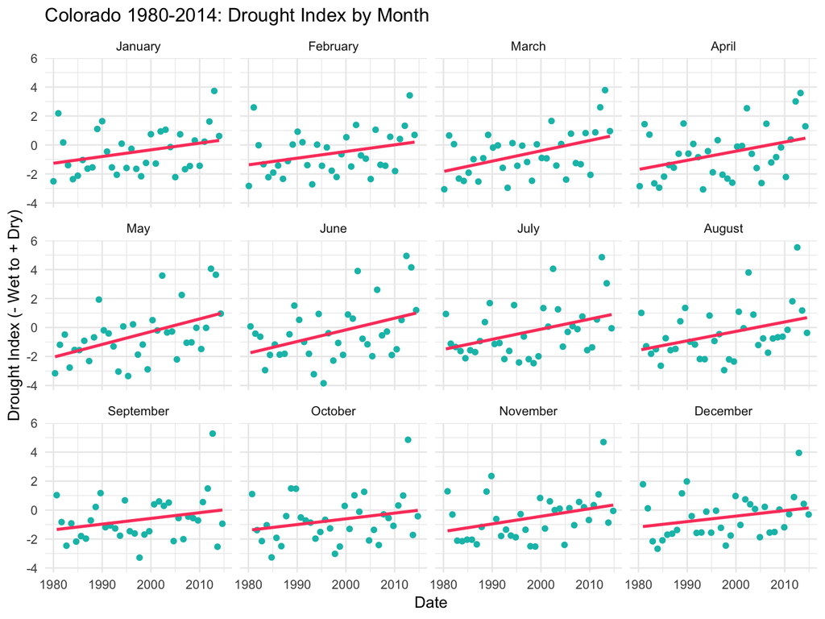

```r
# drought plot
ggplot(co_di, aes(x=Date, y=mean_pdi_invert)) +
  geom_point(color = "#06beb6") +
  geom_smooth(method = "lm", se = F, color = "#fc466b") +
  facet_wrap(~month) +
  ylab("Drought Index (- Wet to + Dry)") +
  ggtitle("Colorado 1980-2014: Drought Index by Month") +
  theme_minimal()
```

## Wildfires

Using US Forest Service historic wildfire shape file data and subletting to Colorado from 1980 to 2014.

```r
# import wildfires for US
wildfire <- st_read(dsn = "./data/wf_usfs_1980_2016/",
                    layer = "wf_usfs_1980_2016")
# subset to colorado and limit to time period of drought index
co_fires <- wildfire %>%
  filter(STATE == "Colorado") %>%
  filter(STARTDATED <= "2014-12-31") %>%
  filter(Duplicate_ == 0) %>%
  mutate(Date = lubridate::floor_date(STARTDATED, unit = "months"))

# extract fire coords
fire_coords <- data.frame(st_coordinates(co_fires))

# join in with co fires
co_fire_summary <- co_fires %>%
  bind_cols(fire_coords) %>%
  group_by(Date) %>%
  summarise(n_fires = n(), total_acres = sum(TOTALACRES)) %>%
  mutate(month = factor(months(Date),
    levels = c("January", "February", "March", "April", "May", "June", "July",
               "August", "September", "October", "November", "December")))

# remove sf geometrey
st_geometry(co_fire_summary) <- NULL
```

### Plot of Colorado Number of Wildfire Numbers 1980-2014

Plotting number of wildfires of any size by month during the study period. The number of wildfires has been increasing over time for the summer months of June, July, and August.

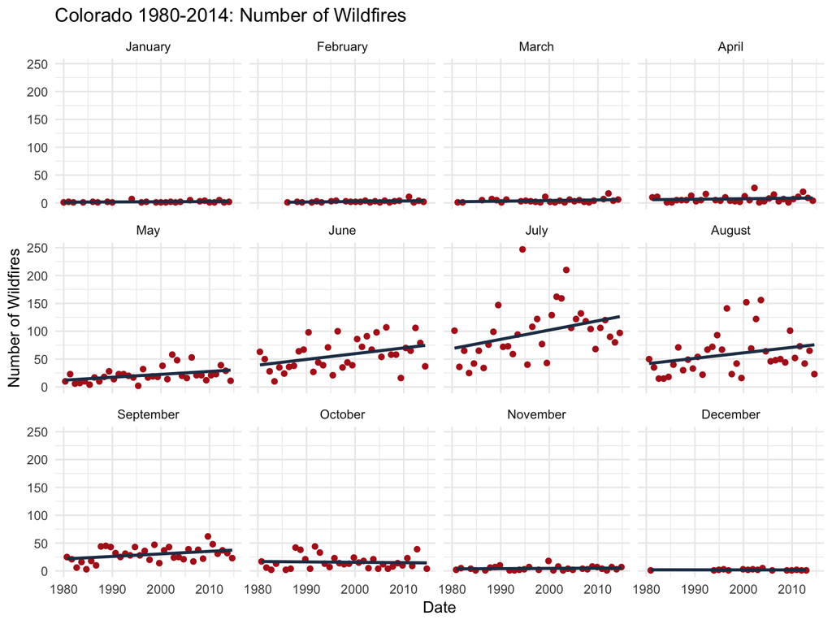

```r
# plot
ggplot(co_fire_summary, aes(x=Date, y = n_fires)) +
  geom_point(color = "#b21f1f") +
  geom_smooth(method = "lm", se=F, color = "#243b55") +
  facet_wrap(~month) +
  ylab("Number of Wildfires") +
  ggtitle("Colorado 1980-2014: Number of Wildfires") +
  theme_minimal()
```

## Preliminary Predictive Model

I want to build a predictive model to model the probability of a large fire event >1000 acres for a given area based on drought index, temperature, precipitation. I think population density should also be accounted for, but I’m not sure if it should go in a model.

First, I need to regrid the nc drought raster to find out the group ID each fire is in. I’m going to create a new raster of the drought index for just Colorado.

```r
# define extent of colorado
e <- extent(c(-110,-102.5, 35, 42.5))
# empty 3x3 raster
r <- raster(e, nrow=3, ncol=3)
# rasterize group id and coordinates of pdi and assign each cell the group/region id
pdi_r <- rasterize(pdsi_df[,2:3], r, pdsi_df[,1], fun=mean)
```

### Output of Large Fires

```r
# summary of fires
fire_size_summary <- co_fires %>%
  group_by(SIZECLASS) %>%
  summarise(n = n(),mean_acre = mean(TOTALACRES), sd_acres = sd(TOTALACRES),
            min_acres = min(TOTALACRES), max_acres = max(TOTALACRES))
# remove geometry
st_geometry(fire_size_summary) <- NULL
# print fire summary
fire_size_summary
```

|  | SIZECLASS | n | mean_acre | sd_acres | min_acres | max_acres |
| --- | --- | --- | --- | --- | --- | --- |
| 1 | A | 7094 | 1.062363e-01 | 2.950293e-02 | 0.00 | 0.30 |
| 2 | B | 2692 | 1.552218e+00 | 1.772482e+00 | 0.23 | 9.35 |
| 3 | C | 382 | 3.060649e+01 | 2.167507e+01 | 10.00 | 98.00 |
| 4 | D | 107 | 1.701850e+02 | 5.384213e+01 | 100.00 | 298.00 |
| 5 | E | 67 | 5.053627e+02 | 1.786348e+02 | 300.00 | 944.00 |
| 6 | F | 42 | 2.131776e+03 | 1.121252e+03 | 1000.00 | 4400.00 |
| 7 | G | 19 | 2.981111e+04 | 3.500959e+04 | 5538.00 | 137760.00 |

For efficiency purposes, I’m going to limit only to fires that burned over 1000 acres. So fires of size F and G classification.

```r
# subset to large fire events
big_fire_events <- co_fires %>% filter(SIZECLASS %in% c("F", "G"))
```

Finding where each fire occured in the PDI region based on location and extracting the group value form the raster where the fire coordinates lie.

```r
# extract fire coords
fire_coords <- st_coordinates(big_fire_events)
# assign group id to fire locations dataframe
big_fire_events$group <- as.character(extract(pdi_r, fire_coords))
# create outcome variable
big_fire_events <- big_fire_events %>%
  mutate(outcome = 1)
```

Plot to check fire events by regional group.

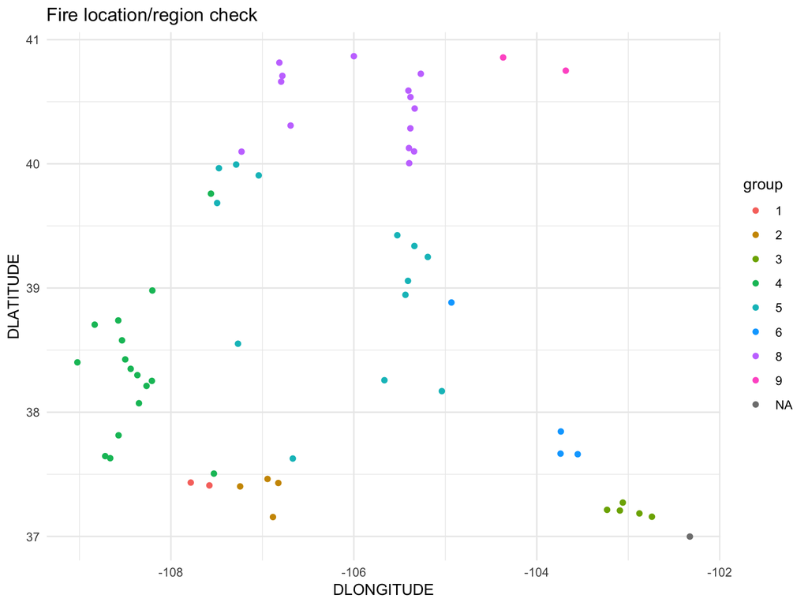

```r
ggplot(big_fire_events, aes(x=DLONGITUDE, y=DLATITUDE,
                            group = group, color = group, fill=group)) +
  geom_point() +
  ggtitle("Fire location/region check") +
  theme_minimal()
```

Setting up time series of fire and drought index.

```r
drought_fires <- pdsi_df %>%
  dplyr::select(-lon, -lat) %>%
  gather(key = date, value = pdi, -group) %>%
  mutate(pdi_invert = -(pdi),
    Date = as.Date(gsub("X", "", gsub("\\.","-", date))),
    group = as.character(group),
    month = lubridate::month(Date),
    month_fct = factor(months(Date), levels = c("January", "February", "March",
      "April", "May", "June", "July", "August", "September", "October",
      "November", "December")),
    season = as.factor(case_when(month %in% c(12,1,2) ~ "winter",
                       month %in% 3:5 ~ "spring",
                       month %in% 6:8 ~ "summer",
                       month %in% 9:11 ~ "fall"))) %>%
  dplyr::select(-date) %>%
  left_join(big_fire_events, by = c("group", "Date")) %>%
  mutate(outcome = ifelse(is.na(outcome), 0, outcome))
```

Checking the relationship of drought index and propotion of fires by bins of inverted pdi and observed fire events.

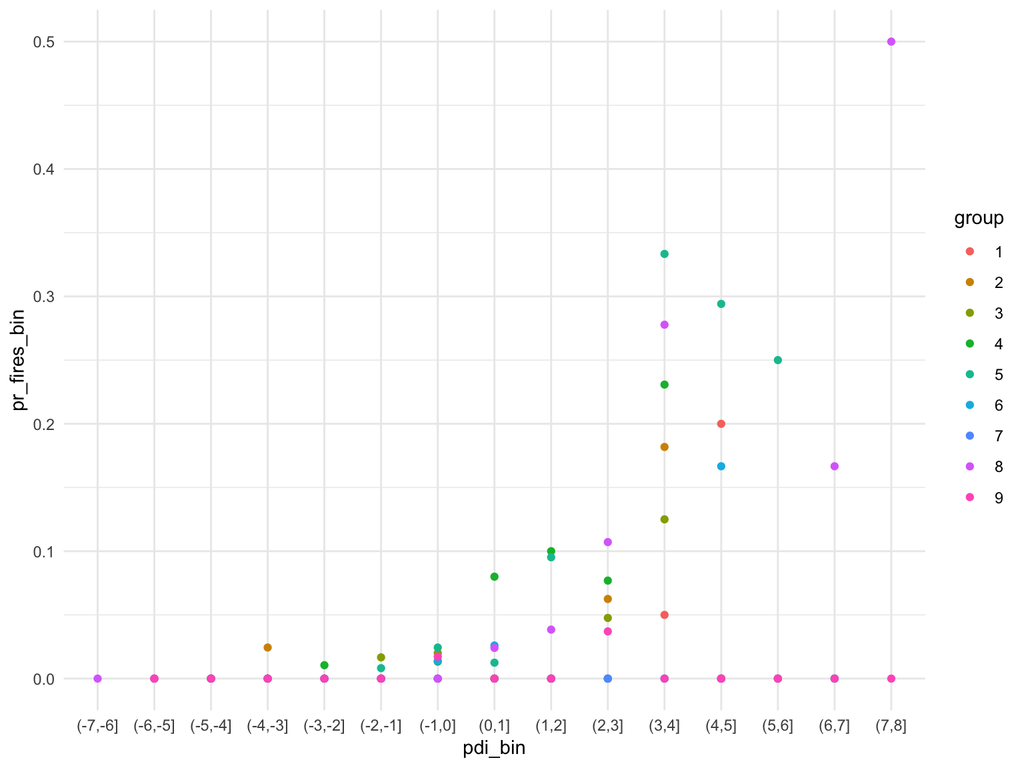

```r
pdi_bin <- drought_fires %>%
  mutate(pdi_bin = cut(pdi_invert, breaks = seq(-8, 8))) %>%
  group_by(pdi_bin, group) %>%
  summarise(n_fires = sum(outcome), n = n(), pr_fires_bin = n_fires/n)


# 408 months in time period
ggplot(pdi_bin, aes(x=pdi_bin, y = pr_fires_bin, group=group, color = group)) +
  geom_point() +
  theme_minimal()
```

Simple logistic model accounting for within area..

```r
# mixed model
logit_mod <- lme4::glmer(outcome ~ pdi_invert + (1|group),
                         family = binomial(), data = drought_fires)

# likelihood
summary(logit_mod)
```

```
## Generalized linear mixed model fit by maximum likelihood (Laplace
##   Approximation) [glmerMod]
##  Family: binomial  ( logit )
## Formula: outcome ~ pdi_invert + (1 | group)
##    Data: drought_fires
##
##      AIC      BIC   logLik deviance df.resid
##    513.3    532.0   -253.6    507.3     3787
##
## Scaled residuals:
##     Min      1Q  Median      3Q     Max
## -0.8516 -0.1192 -0.0734 -0.0451 26.6976
##
## Random effects:
##  Groups Name        Variance Std.Dev.
##  group  (Intercept) 1.214    1.102
## Number of obs: 3790, groups:  group, 9
##
## Fixed effects:
##             Estimate Std. Error z value Pr(>|z|)
## (Intercept) -4.92547    0.43032 -11.446   <2e-16 ***
## pdi_invert   0.54890    0.05865   9.359   <2e-16 ***
## ---
## Signif. codes:  0 '***' 0.001 '**' 0.01 '*' 0.05 '.' 0.1 ' ' 1
##
## Correlation of Fixed Effects:
##            (Intr)
## pdi_invert -0.290
```

Plot of predicted response by region

```r
drought_fires$pr <- predict(logit_mod, type = "response")

# new drought index
pdi_invert <- rep(seq(-7, 7, by = 0.5), times=9)
group <- rep(as.factor(seq(1:9)), each = 29)

new_pr_data <- data.frame(pdi_invert, group)
summary(drought_fires$pdi_invert)
```

```
##    Min. 1st Qu.  Median    Mean 3rd Qu.    Max.
## -6.7087 -2.0680 -0.6316 -0.5135  0.6765  7.9631
```

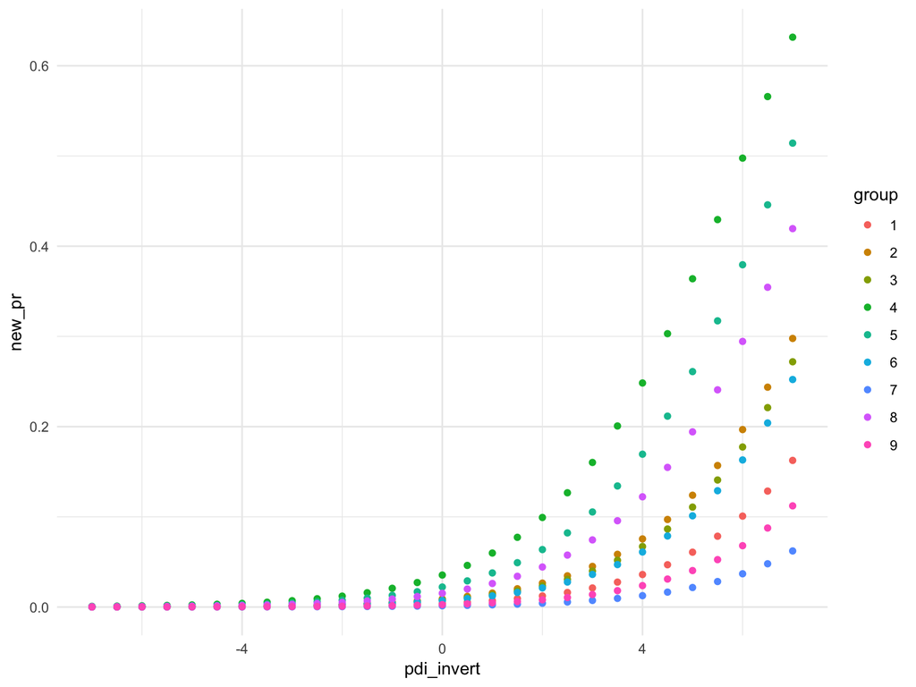

```r
new_pr_data$new_pr <- predict(logit_mod, type = "response", newdata = new_pr_data)

# plot of predicted response by region
ggplot(new_pr_data, aes(x=pdi_invert, y=new_pr, group=group, color = group)) +
  geom_point() +
  theme_minimal()
```

## Conclusion

The increasing drought index during the summer months and the increasing number of wildfires leads me to believe that building a predictive model of likelihood of a wildfire occurring based on factors like drought, temperature, precipitation, and vegetative land cover would be a successful capstone project.